# Political Contributions

Ted Dickey

2020-10-12

# Introduction

1.1 The purpose of this document is to analyze data from the FEC website and illustrate how Cincinnati money influences politics.

1.2 The data is a subset of all Cincinnati data from 2015-present, reported on the FEC website in tabular form on this page: https://www.fec.gov/data/receipts/individual-contributions/. The subset includes only contributions where a political party is affiliated with the committee receiving the contribution. **This means all non-affiliated super PAC committees are not included in this data.**

1.3 This report will assist the individual to better understand how money from Cincinnati influences politics through the usage of summary statistics and the presentation of the data in a more visual format that includes summary statistics, interactive tables, charts, and some simple analytics.

# Packages Required

| Package | Purpose |
| --- | --- |
| tidyverse | Core packages for data analysis and manipulation |
| lubridate | For parsing date-time data |
| knitr | General-purpose literate program engine for output control |
| readr | For importing cSV data rectangular data |
| scales | For transforming and rescaling data |
| stats | For creating interactive tables |
| skimr | For general summary statistics about data set |
| prettydoc | Creating documents in R Markdown |
| car | Companion to applied regression analysis |
| ggcharts | Creating common chart type visualizations |
| DT | Rendering of HTML tables |
| gridExtra | Provides miscellaneous functions for grids |
| kableExtra | for table placement in html |

# Data Preparation

The following data cleaning tasks were performed:

- Data for individual contributions made prior to January 2015 were omitted.
- Any records with contribution value = $0 were omitted.
- Data in employer and occupation columns were modified to “UNKNOWN” for NAs or missing values.
- Occupation entries as a variation of ‘retired’ were unitified to only being ’retired.
- Contribution date column was recast from a character vector to a Date format.

## Source Data Explanation

The data includes the following variables:

- Contributor Name (first and last)
- Contributor Street Address
- Contributor Employer and Occupation
- Date of Contribution
- Contribution Amount (The amount contributed in this specific instance of a contribution being made. Positive values reflect a donation whereas negative values reflect a refund of a previous donation)
- Contributor Aggregate YTD (The total amount of contributions made year-to-date by this individual contributor)
- Committee Name (Name of the political committee receiving the contribution)
- Committee Type (Presidential, senate, house, party or political action committee)
- Committee Party Affiliation
- Qualification (Whether the committee type is Qualified or Nonqualified)

In the dataset, there are **57351** observations.

The number of missing values that have been recoded as “UNKNOWN” are:

- Contributor’s Employer: 9189
- Contributor’s Occouptaion: 1570

The following fields have missing values:

- Missing 6 for contributor’s Last name.
- Missing 17 for contributor’s street name.

## Summary Information

The net total contribution receipt amount is **$20,342,540**. The average contribution amount is $355. The median contribution amount is $50. This would tend to indicate there is right skewness in the contribution amounts.

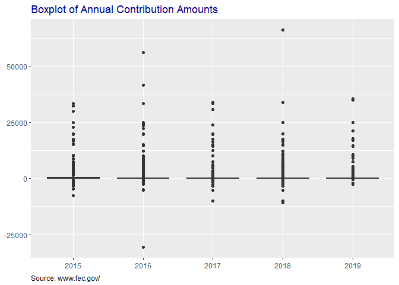

Viewing the variance in contribution amounts by year, the boxplots clearly illustrate the skewness in the amounts given from 2015 to 2019 by the significant presence of outliers.

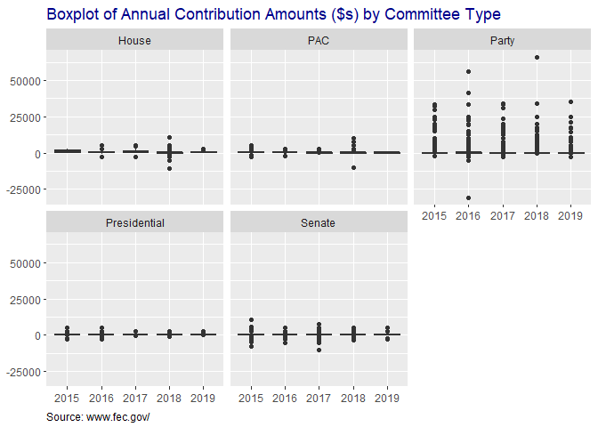

When segregating the annual contribution amount data, it becomes more apparent that the skewness observed coud primarily be attributed to the significant degree of variance in Party donations.

The below table displays the amounts given by Party Affiliation

| Committee Party Affiliaton | Amount (in $s) |
| --- | --- |
| REPUBLICAN PARTY | 10,905,706 |
| DEMOCRATIC PARTY | 9,372,506 |
| INDEPENDENT | 23,386 |
| DEMOCRATIC-FARMER-LABOR | 21,237 |
| LIBERTARIAN PARTY | 12,027 |
| GREEN PARTY | 7,677 |

The Republican party committees have slighly outraised their Democratic party counterparts since 2015. The other parties are substantially behind in fundraising during the same period.

## Interactive Table

A random sample of 2000 observations were taken from the primary data for the interactive table below. Individual columns can be sorted ascending or desending using the arrows to the right of the heading. A drop down box is provided to select the number of entries to be displayed per page. There is an area below the column hedings for filtering the data. Additionally, there is a navigation bar below the table to view other pages. A search box is included for searching for specific terms. The first name and street address columns have been removed for privacy.

| contributor_last_name | contributor_employer | contributor_occupation | contribution_receipt_date | contribution_receipt_amount | committee_name | committee_type | qualification | committee_party_affiliation |
| --- | --- | --- | --- | --- | --- | --- | --- | --- |
| ENGEL | ENGEL AUTO SERVICE INC. | OFFICE MANAGER | 2017-12-20 | 50 | REPUBLICAN NATIONAL COMMITTEE | Party | Qualified | REPUBLICAN PARTY |
| ACH | RETIRED | RETIRED | 2016-08-12 | 400 | DONALD J. TRUMP FOR PRESIDENT, INC. | Presidential |  | REPUBLICAN PARTY |
| JOINER | UNEMPLOYED | NOT EMPLOYED | 2018-02-25 | 250 | COMMITTEE TO ELECT JANET EVERHARD | House |  | DEMOCRATIC PARTY |
| JOHNSON | UNKNOWN | RETIRED | 2018-10-07 | 5 | DCCC | Party | Qualified | DEMOCRATIC PARTY |
| BIANCO | FIFTH THIRD BANK | BANKING | 2018-03-18 | 250 | OHIO DEMOCRATIC PARTY | Party | Qualified | DEMOCRATIC PARTY |
| RUSSELL | VORHIS FUNERAL HOME | FUNERAL DIRECTOR | 2016-07-06 | 40 | DONALD J. TRUMP FOR PRESIDENT, INC. | Presidential |  | REPUBLICAN PARTY |
| RUCHHOFT | UNEMPLOYED | RETIRED | 2018-09-17 | 10 | AFTAB FOR OHIO | House |  | DEMOCRATIC PARTY |
| GOLDSMITH | DEPT OF VETERANS AFFAIRS | PHYSICIAN | 2018-06-29 | 100 | DSCC | Party | Qualified | DEMOCRATIC PARTY |
| PENDLE | UNKNOWN | RETIRED | 2018-12-20 | 50 | DCCC | Party | Qualified | DEMOCRATIC PARTY |
| BAIN | UNEMPLOYED | NOT EMPLOYED | 2016-04-05 | 75 | BERNIE 2016 | Presidential |  | DEMOCRATIC PARTY |

[output cut: 1990 more lines]

# Simple Analysis & Trends

In this section of the report, three visualizations will be created to enhance our understanding of political contribution amounts, their variance over time, compared to to each party, and association by committee type.

### Illustration of the variance in contribution amounts from 2015 to present

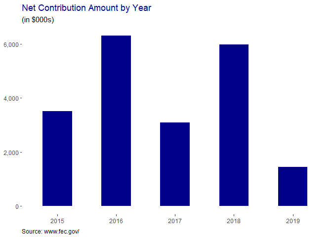

Contribution amounts appear to peak during election years (2016 and 2018) then recedue during the off-year periods.

### Contribution amount comparisons by each party for two most recent cycles

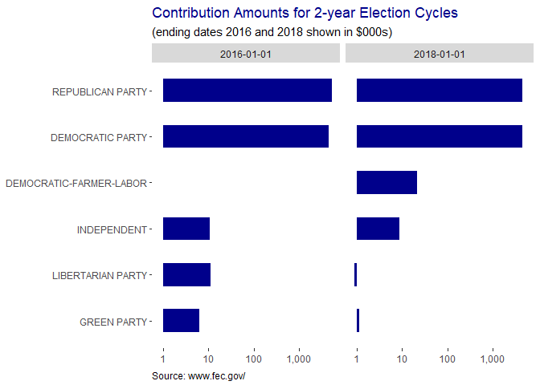

The table above clearly illustrates how the Republican and Democratic parties dominate the field in both election cycles for contributions as compared to all others in the data group. Notable is the entrance of ‘Democratic-Farmer-Labor’ party in the latter cycle.

### Illustration of the association between the amount contributed and committee type.

The table and chart below illustrates the association between the amount contributed and committee type.

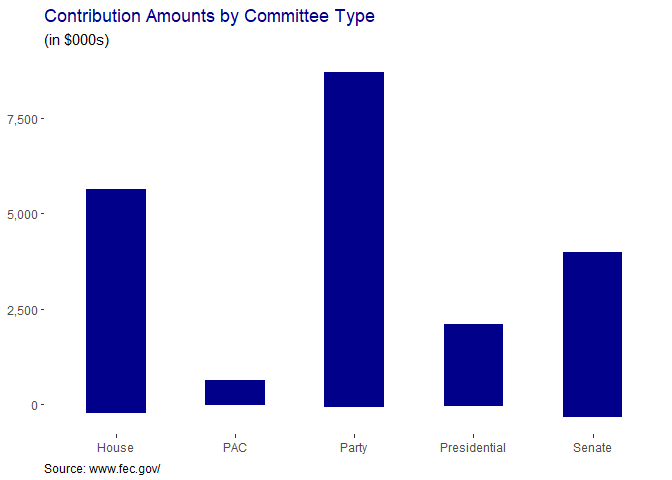

| Committee Type | Amount (in $s) |
| --- | --- |
| Party | 8,625,001 |
| House | 5,406,700 |
| Senate | 3,648,605 |
| Presidential | 2,062,595 |
| PAC | 599,639 |

Most contributions have been earmarked to the party committees. This is followed by donations to House and then Senate committees.

# Directed Analysis

### Which Cincinnati residents spend the most money on politics? Where does it go?

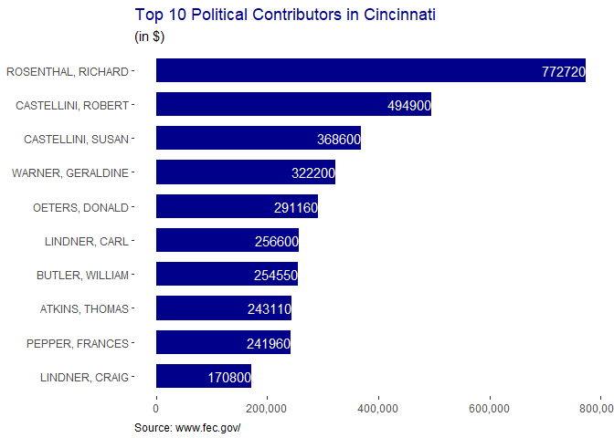

As indicated in the bar chart above, Mr. Rosenthall is the top contributor from the Cincinnati region since 2015 with $772,720 spent. He is followed by Robert Castellini, with $494,900 and Susan Castellini, with $368,600.

Where are the funds going?

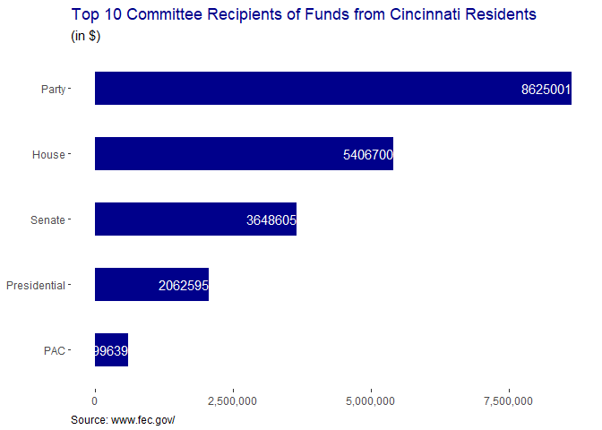

### Who has made the most individual contributions? What do you think is going on here?

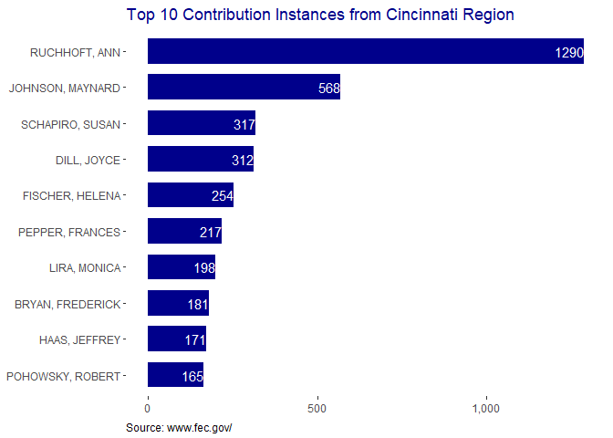

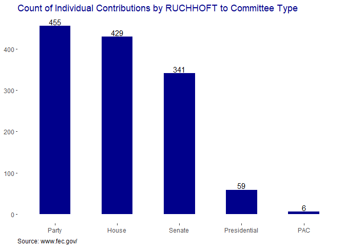

As indicated in the visual above, Ruchhoft made 455 individual party contributions, followed closely with 429 to House committee types. Alternatively, we can view this in terms of amount spent for each committee type as pictured below.

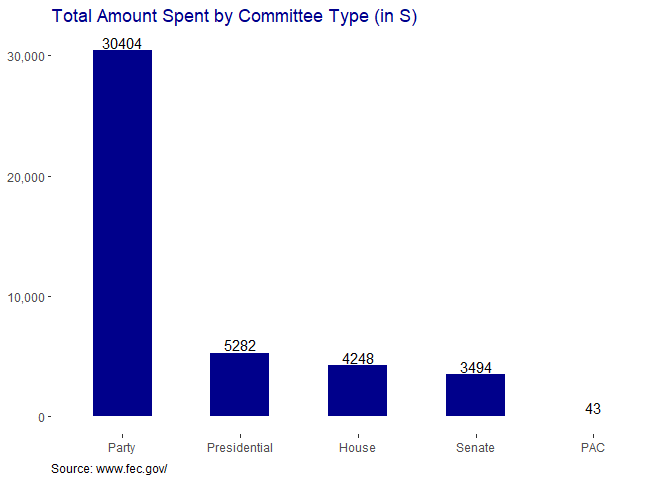

| committee_party_affiliation | Count | Amount |
| --- | --- | --- |
| DEMOCRATIC PARTY | 1290 | 43471 |

Given that all the individual contributions has been earmarked for the Democratic party, it is conceivable that the contributor belongs to the Democratic party.

### Which employers are heavily represented in the data?

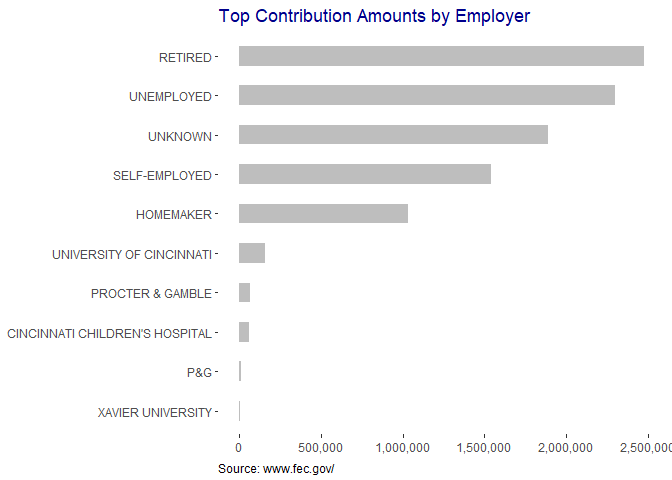

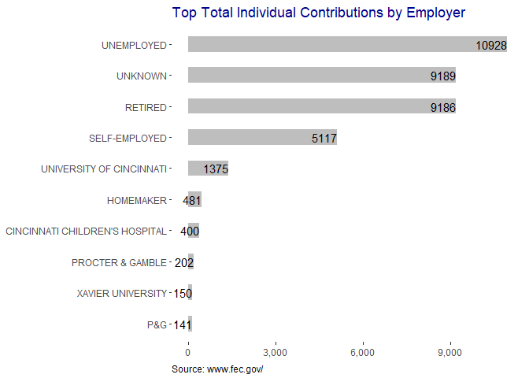

There are a couple of ways to determine what constitutes being ‘heavily represented’. Based on the amount of money spent in contributions by employer, retired individuals could be considered the most heavilly represented followed by the unemployed with $2,472,895 and $2,298,257, respectively.

If we were to view this as being based on the total number of individual contributions, individuals who are self-described as being unemployed, followed closely by those individuals that did not identify an employer and retired people could be considered the most heavily represented with 10,928, 9,189, and 9,186, respectively.

Excluding individuals that are unemployed, retired, self-employed, homemakers or employer status unknown, we get the following display

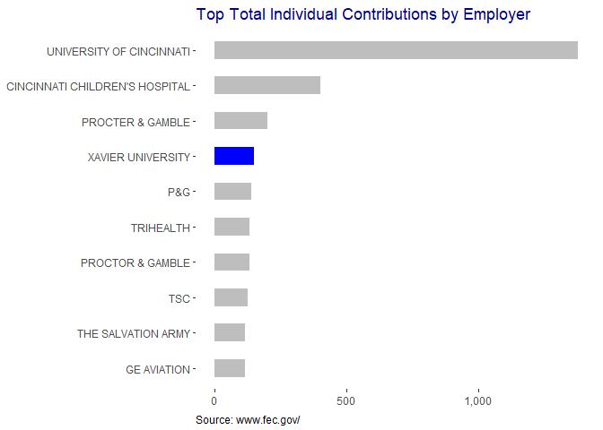

### How many individuals working for Xavier have made at least one contribution?

| Employee | Instances | Total Amount(in $s) |
| --- | --- | --- |
| TRAUB, GEORGE W | 70 | 632 |
| TRAUB, GEORGE | 28 | 223 |
| HOLLAND, MARTHA | 10 | 1,350 |
| JOHNSON, ELIZABETH | 6 | 537 |
| LEVYA-GARDNER, BRENDA | 4 | 250 |
| TOWNSEND, ROBERT | 4 | 196 |
| JACK, DARCY | 3 | 404 |
| SCHULTZ, JANET | 3 | 250 |
| TOEPKER, TERRY | 3 | 600 |
| TRACEY, ANN | 3 | 1,750 |

[output not shown]

# Self-Directed Analysis

### Comparison of Amounts Contributed and Refunded

| Refunds | RefundPercent | Contributions | ContributionPercent | RefundSum | ContributionSum |
| --- | --- | --- | --- | --- | --- |
| 501 | 0.0087 | 56850 | 0.9913 | -715648.1 | 21058188 |

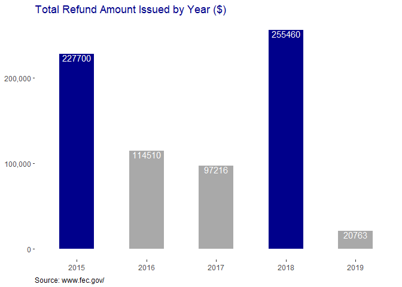

Viewing the same data by year of refund, we see that significantly larger refunds were issued in 2015 and 2018 as compared to all other years in the study.

Finding the top 10 refunds by listed employer generates the below chart. Interestingly, those that identify as being unemployed top the chart in refunds with $131,666. This group is followed by those individuals that have reported being self-employed and then those that did not indicate employer.

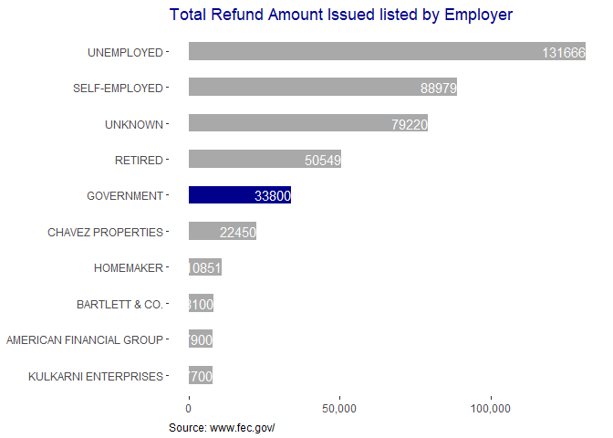

Excluding those individuals that are self-reported as being unemployed, self-employed, homemaker, or unknown, the table below displays the top refund amounts by listed companies.

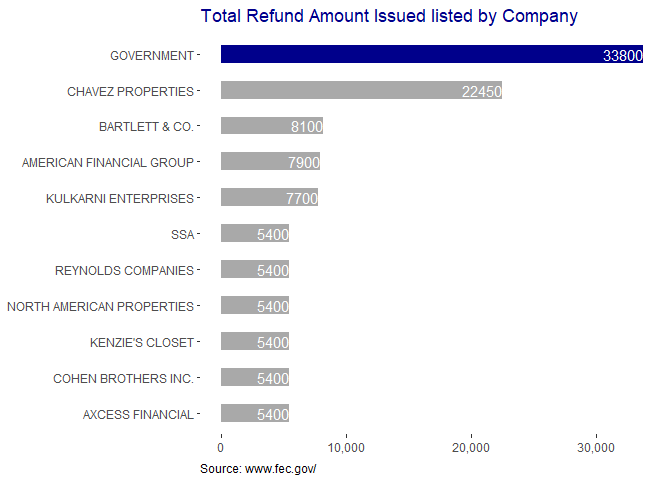

Who is taking more than giving?

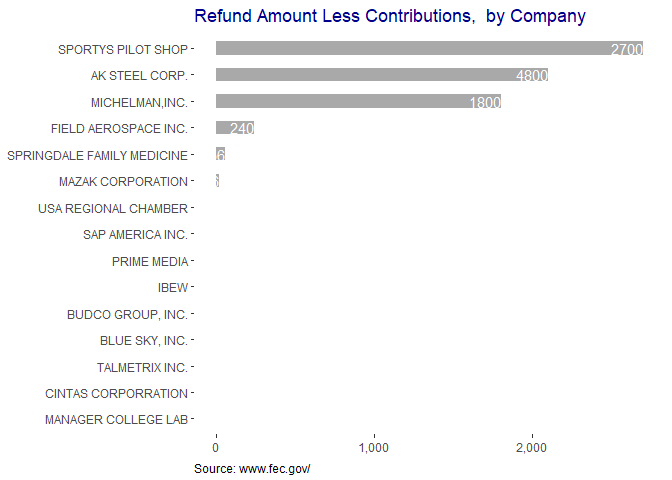

Sporty Pilot Shop, AK Steel Corp, and Michelman, Inc. appear to have received refunds of an amount greater than their contributions, over the selected periods.

### Who is your daddy?

In this final self-directed analysis, I would like to know which individuals are substially contributing to republican party committees, democratic party committees.

I intend to answer this question by grouping the data by party affiliation, and then filtering out those which are not Republican or Demecratic Party. Next, I will get a cumulative sum of net contributions by each individual. Finally, I will select the top 10 donors to each party and graph the results using a cumulative chart, followed by a totals segregated by year.

Now that we have taken a look at how much is being spent, by who, and to which races and parties, who are the big spenders for each party? Lets first take a look at the top contributors to each party

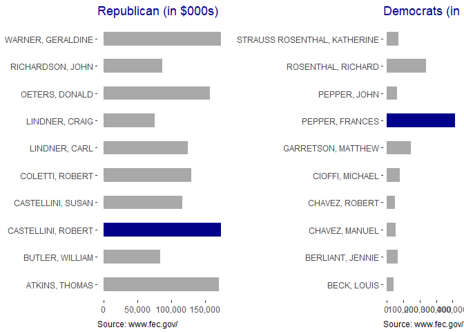

Overall, Robert Castellini has contributed the most to the Republican party since 2015, Frances Pepper has led for the Democrats.

As for the annual breakdowns,

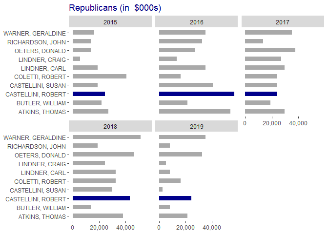

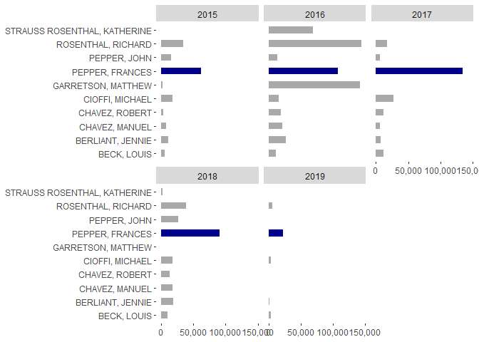

Notice that the cumulative leaders are not neccesarily leading in each and every year.